# Decorrelation-Based Feature Discovery: Personality Age

Jose Tamez

2024-01-05

# 1 Effect of UPSTM-Based Decorrelation on Feature Discovery

## 1.1 Loading the libraries

```r
library("FRESA.CAD")
library(readxl)
library(igraph)
library(umap)
library(tsne)
library(entropy)

op <- par(no.readonly = TRUE)
pander::panderOptions('digits', 3)
pander::panderOptions('table.split.table', 400)
pander::panderOptions('keep.trailing.zeros',TRUE)
```

## 1.2 Material

Data Source https://quantdev.ssri.psu.edu/tutorials/intro-basic-exploratory-factor-analysis

“For this example, we use data from the web that are collected and distributed at https://openpsychometrics.org/_rawdata/. The data were obtained from 19,719 participants (rows) who provided answers to the Big Five Personality Test, constructed with items from the International Personality Item Pool. Data columns include gender, age, race, native language, country, and answers to the 50 likert rated statements (1-5;0 if missed; 1 was labeled as “strongly disagree”, 2 was labeled as “disagree”, 3 was labeled as “neither agree not disagree”, 4 was labeled as “agree” and 5 was labeled as “strongly agree”.) The original files can be obtaned at http://openpsychometrics.org/_rawdata/BIG5.zip”

## 1.3 The Data

```r
BigData <- as.data.frame(read_excel("~/GitHub/LatentBiomarkers/Data/BigData.xlsx"))

BigData[BigData==0] <- NA
BigData <- BigData[complete.cases(BigData),]
BigData <- BigData[BigData$age<100,]

BigData <- BigData[,-c(1,3,5,6,7)]

BigData$gender <- 1*(BigData$gender==1)


BigData$age <- log10(BigData$age)
```

### 1.3.1 Standarize the names for the reporting

```r
studyName <- "PersonalityAge"
dataframe <- BigData
outcome <- "age"

thro <- 0.20
cexheat <- 0.35
loops <- 30
```

## 1.4 Generaring the report

### 1.4.1 Libraries

Some libraries

```r
library(psych)
library(whitening)
library("vioplot")
library("rpart")
library(multiColl)
library(car)

source("C:/Users/jtame/Documents/GitHub/LatentBiomarkers/RMD/RepeatedLinearCV.R")
```

### 1.4.2 Data specs

```r
pander::pander(c(rows=nrow(dataframe),col=ncol(dataframe)-1))
```

| rows | col |
| --- | --- |
| 19303 | 51 |

```r
varlist <- colnames(dataframe)
varlist <- varlist[varlist != outcome]

largeSet <- length(varlist) > 1500
```

### 1.4.3 Training and testing sets

```r
set.seed(1)
trainsamples <- sample(nrow(dataframe),3*nrow(dataframe)/4)

trainingset <- dataframe[trainsamples,]
testingset <- dataframe[-trainsamples,]

pander::pander(t(summary(trainingset)))
```

| **age** | Min. :1.114 | 1st Qu.:1.255 | Median :1.342 | Mean :1.385 | 3rd Qu.:1.491 | Max. :1.996 |
| --- | --- | --- | --- | --- | --- | --- |
| **gender** | Min. :0.0000 | 1st Qu.:0.0000 | Median :0.0000 | Mean :0.3903 | 3rd Qu.:1.0000 | Max. :1.0000 |
| **E1** | Min. :1.000 | 1st Qu.:2.000 | Median :3.000 | Mean :2.644 | 3rd Qu.:4.000 | Max. :5.000 |
| **E2** | Min. :1.000 | 1st Qu.:2.000 | Median :3.000 | Mean :2.756 | 3rd Qu.:4.000 | Max. :5.000 |
| **E3** | Min. :1.000 | 1st Qu.:3.000 | Median :4.000 | Mean :3.424 | 3rd Qu.:4.000 | Max. :5.000 |
| **E4** | Min. :1.000 | 1st Qu.:2.000 | Median :3.000 | Mean :3.149 | 3rd Qu.:4.000 | Max. :5.000 |
| **E5** | Min. :1.000 | 1st Qu.:2.000 | Median :4.000 | Mean :3.436 | 3rd Qu.:5.000 | Max. :5.000 |
| **E6** | Min. :1.000 | 1st Qu.:1.000 | Median :2.000 | Mean :2.444 | 3rd Qu.:3.000 | Max. :5.000 |
| **E7** | Min. :1.000 | 1st Qu.:2.000 | Median :3.000 | Mean :2.873 | 3rd Qu.:4.000 | Max. :5.000 |
| **E8** | Min. :1.000 | 1st Qu.:2.000 | Median :3.000 | Mean :3.373 | 3rd Qu.:4.000 | Max. :5.000 |
| **E9** | Min. :1.000 | 1st Qu.:2.000 | Median :3.000 | Mean :3.102 | 3rd Qu.:4.000 | Max. :5.000 |
| **E10** | Min. :1.000 | 1st Qu.:3.000 | Median :4.000 | Mean :3.581 | 3rd Qu.:5.000 | Max. :5.000 |
| **N1** | Min. :1.000 | 1st Qu.:2.000 | Median :3.000 | Mean :3.259 | 3rd Qu.:4.000 | Max. :5.000 |
| **N2** | Min. :1.000 | 1st Qu.:2.000 | Median :3.000 | Mean :3.236 | 3rd Qu.:4.000 | Max. :5.000 |
| **N3** | Min. :1.000 | 1st Qu.:3.000 | Median :4.000 | Mean :3.844 | 3rd Qu.:5.000 | Max. :5.000 |
| **N4** | Min. :1.000 | 1st Qu.:2.000 | Median :3.000 | Mean :2.747 | 3rd Qu.:4.000 | Max. :5.000 |
| **N5** | Min. :1.000 | 1st Qu.:2.000 | Median :3.000 | Mean :2.948 | 3rd Qu.:4.000 | Max. :5.000 |
| **N6** | Min. :1.000 | 1st Qu.:2.000 | Median :3.000 | Mean :2.979 | 3rd Qu.:4.000 | Max. :5.000 |
| **N7** | Min. :1.000 | 1st Qu.:2.000 | Median :3.000 | Mean :3.155 | 3rd Qu.:4.000 | Max. :5.000 |
| **N8** | Min. :1.000 | 1st Qu.:2.000 | Median :3.000 | Mean :2.814 | 3rd Qu.:4.000 | Max. :5.000 |
| **N9** | Min. :1.000 | 1st Qu.:2.000 | Median :3.000 | Mean :3.134 | 3rd Qu.:4.000 | Max. :5.000 |
| **N10** | Min. :1.000 | 1st Qu.:2.000 | Median :3.000 | Mean :2.843 | 3rd Qu.:4.000 | Max. :5.000 |
| **A1** | Min. :1.000 | 1st Qu.:1.000 | Median :2.000 | Mean :2.309 | 3rd Qu.:3.000 | Max. :5.000 |
| **A2** | Min. :1.000 | 1st Qu.:3.000 | Median :4.000 | Mean :3.928 | 3rd Qu.:5.000 | Max. :5.000 |
| **A3** | Min. :1.000 | 1st Qu.:1.000 | Median :2.000 | Mean :2.171 | 3rd Qu.:3.000 | Max. :5.000 |
| **A4** | Min. :1.000 | 1st Qu.:4.000 | Median :4.000 | Mean :4.031 | 3rd Qu.:5.000 | Max. :5.000 |
| **A5** | Min. :1.000 | 1st Qu.:1.000 | Median :2.000 | Mean :2.164 | 3rd Qu.:3.000 | Max. :5.000 |
| **A6** | Min. :1.0 | 1st Qu.:3.0 | Median :4.0 | Mean :3.9 | 3rd Qu.:5.0 | Max. :5.0 |
| **A7** | Min. :1.000 | 1st Qu.:1.000 | Median :2.000 | Mean :2.157 | 3rd Qu.:3.000 | Max. :5.000 |
| **A8** | Min. :1.000 | 1st Qu.:3.000 | Median :4.000 | Mean :3.771 | 3rd Qu.:5.000 | Max. :5.000 |
| **A9** | Min. :1.000 | 1st Qu.:3.000 | Median :4.000 | Mean :3.944 | 3rd Qu.:5.000 | Max. :5.000 |
| **A10** | Min. :1.000 | 1st Qu.:3.000 | Median :4.000 | Mean :3.682 | 3rd Qu.:5.000 | Max. :5.000 |
| **C1** | Min. :1.000 | 1st Qu.:3.000 | Median :3.000 | Mean :3.321 | 3rd Qu.:4.000 | Max. :5.000 |
| **C2** | Min. :1.000 | 1st Qu.:2.000 | Median :3.000 | Mean :2.984 | 3rd Qu.:4.000 | Max. :5.000 |
| **C3** | Min. :1.000 | 1st Qu.:3.000 | Median :4.000 | Mean :3.986 | 3rd Qu.:5.000 | Max. :5.000 |
| **C4** | Min. :1.000 | 1st Qu.:2.000 | Median :3.000 | Mean :2.655 | 3rd Qu.:4.000 | Max. :5.000 |
| **C5** | Min. :1.000 | 1st Qu.:2.000 | Median :3.000 | Mean :2.701 | 3rd Qu.:4.000 | Max. :5.000 |
| **C6** | Min. :1.000 | 1st Qu.:2.000 | Median :3.000 | Mean :2.927 | 3rd Qu.:4.000 | Max. :5.000 |
| **C7** | Min. :1.000 | 1st Qu.:3.000 | Median :4.000 | Mean :3.653 | 3rd Qu.:5.000 | Max. :5.000 |
| **C8** | Min. :1.000 | 1st Qu.:2.000 | Median :2.000 | Mean :2.486 | 3rd Qu.:3.000 | Max. :5.000 |
| **C9** | Min. :1.000 | 1st Qu.:2.000 | Median :3.000 | Mean :3.226 | 3rd Qu.:4.000 | Max. :5.000 |
| **C10** | Min. :1.000 | 1st Qu.:3.000 | Median :4.000 | Mean :3.637 | 3rd Qu.:4.000 | Max. :5.000 |
| **O1** | Min. :1.0 | 1st Qu.:3.0 | Median :4.0 | Mean :3.7 | 3rd Qu.:5.0 | Max. :5.0 |
| **O2** | Min. :1.000 | 1st Qu.:1.000 | Median :2.000 | Mean :2.142 | 3rd Qu.:3.000 | Max. :5.000 |
| **O3** | Min. :1.000 | 1st Qu.:4.000 | Median :4.000 | Mean :4.129 | 3rd Qu.:5.000 | Max. :5.000 |
| **O4** | Min. :1.000 | 1st Qu.:1.000 | Median :2.000 | Mean :2.073 | 3rd Qu.:3.000 | Max. :5.000 |
| **O5** | Min. :1.000 | 1st Qu.:3.000 | Median :4.000 | Mean :3.874 | 3rd Qu.:5.000 | Max. :5.000 |
| **O6** | Min. :1.000 | 1st Qu.:1.000 | Median :1.000 | Mean :1.791 | 3rd Qu.:2.000 | Max. :5.000 |
| **O7** | Min. :1.000 | 1st Qu.:4.000 | Median :4.000 | Mean :4.076 | 3rd Qu.:5.000 | Max. :5.000 |
| **O8** | Min. :1.000 | 1st Qu.:2.000 | Median :3.000 | Mean :3.211 | 3rd Qu.:4.000 | Max. :5.000 |
| **O9** | Min. :1.000 | 1st Qu.:4.000 | Median :4.000 | Mean :4.143 | 3rd Qu.:5.000 | Max. :5.000 |
| **O10** | Min. :1.000 | 1st Qu.:3.000 | Median :4.000 | Mean :4.008 | 3rd Qu.:5.000 | Max. :5.000 |

```r
varlist <- colnames(trainingset)
varlist <- varlist[varlist != outcome]
```

### 1.4.4 Correlation Matrix of the Data

The heat map of the data

```r
par(op)


  par(cex=0.6,cex.main=0.85,cex.axis=0.7)
  cormat <- cor(testingset[,varlist],method="pearson")
  cormat[is.na(cormat)] <- 0
  gplots::heatmap.2(abs(cormat),
                    trace = "none",
  #                  scale = "row",
                    mar = c(5,5),
                    col=rev(heat.colors(5)),
                    main = "Original Correlation",
                    cexRow = cexheat,
                    cexCol = cexheat,
                     srtCol=45,
                     srtRow=45,
                    key.title=NA,
                    key.xlab="|Pearson Correlation|",
                    xlab="Feature", ylab="Feature")
  diag(cormat) <- 0
  pander::pander(max(abs(cormat)))
```

*0.77*

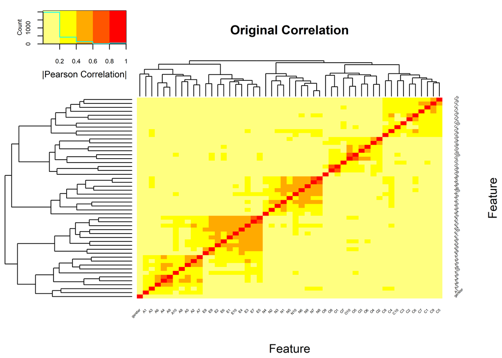

```r
par(op)
```

### 1.4.5 Decorrelating using ILAA

ILAA bootstrapped training and testing sets

```r
#trainage_DE <- ILAA(trainingset,thr=thro,Outcome=outcome,verbose=TRUE)
trainage_DE <- ILAA(trainingset,thr=thro,Outcome=outcome,verbose=TRUE,bootstrap=30)
```

fast | LM | N8 E1 E2 E3 E4 E5 E6 0.74 0.68 0.76 0.54 0.92 0.66

Included: 50 , Uni p: 0.003 , Base Size: 1 , Rcrit: 0.0228362

1 <R=0.525,thr=0.700>, Top: 1< 1 >Fa= 1,<|><>Tot Used: 2 , Added: 1 , Zero Std: 0 , Max Cor: 0.655

2 <R=0.514,thr=0.600>, Top: 5< 1 >Fa= 6,<|><>Tot Used: 12 , Added: 5 , Zero Std: 0 , Max Cor: 0.591

3 <R=0.470,thr=0.500>, Top: 8< 4 >Fa= 11,<|><>Tot Used: 29 , Added: 13 , Zero Std: 0 , Max Cor: 0.559

4 <R=0.373,thr=0.500>, Top: 1< 1 >Fa= 12,<|><>Tot Used: 31 , Added: 1 , Zero Std: 0 , Max Cor: 0.484

5 <R=0.366,thr=0.400>, Top: 4< 2 >Fa= 13,<|><>Tot Used: 36 , Added: 6 , Zero Std: 0 , Max Cor: 0.421

6 <R=0.339,thr=0.400>, Top: 2< 1 >Fa= 15,<|><>Tot Used: 36 , Added: 2 , Zero Std: 0 , Max Cor: 0.400

7 <R=0.329,thr=0.300>, Top: 13< 1 >Fa= 16,<|><>Tot Used: 48 , Added: 21 , Zero Std: 0 , Max Cor: 0.353

8 <R=0.277,thr=0.300>, Top: 6< 1 >Fa= 18,<|><>Tot Used: 48 , Added: 5 , Zero Std: 0 , Max Cor: 0.298

9 <R=0.257,thr=0.200>, Top: 13< 3 >Fa= 20,<|><>Tot Used: 49 , Added: 22 , Zero Std: 0 , Max Cor: 0.265

10 <R=0.226,thr=0.200>, Top: 7< 2 >Fa= 21,<|><>Tot Used: 49 , Added: 7 , Zero Std: 0 , Max Cor: 0.225

11 <R=0.221,thr=0.200>, Top: 2< 1 >Fa= 21,<|><>Tot Used: 49 , Added: 2 , Zero Std: 0 , Max Cor: 0.199

12 <R=0.199,thr=0.200>

[ 12 ], 0.1993877 Decor Dimension: 49 Nused: 49 . Cor to Base: 37 , ABase: 50 , Outcome Base: 0

age gender O9 E5 N8 A4 1 1 1 1 1 1

```r
testage_DE <- predictDecorrelate(trainage_DE,testingset)

attr(trainage_DE,"LatentVariables")
```

[1] “E1” “E2” “E3” “E4” “E6” “E7” “E8” “E9” “E10” “N1” “N2” “N3” [13] “N4” “N5” “N6” “N7” “N9” “N10” “A1” “A2” “A3” “A5” “A6” “A7” [25] “A8” “A9” “A10” “C1” “C3” “C4” “C5” “C6” “C7” “C8” “C9” “C10” [37] “O2” “O3” “O4” “O5” “O6” “O7” “O8” “O10”

```r
attr(trainage_DE,"useDeCorr")
```

[1] TRUE

### 1.4.6 The Formulas

Generating the formulas

```r
theLaFormulas <- getLatentCoefficients(trainage_DE)

theCharformulas <- attr(theLaFormulas,"LatentCharFormulas")
pander::pander(as.matrix(theCharformulas))
```

| **La_E1** | + E1 - (0.175)E5 - (0.412)E7 |
| --- | --- |
| **La_E2** | + E2 + (0.403)E5 + (0.217)E7 |
| **La_E3** | + E3 - (0.356)E5 - (0.300)E7 + (0.034)N8 |
| **La_E4** | - (0.297)E2 + E4 + (0.068)E5 + (0.145)E7 - (0.177)E8 - (0.175)E10 |
| **La_E6** | - (0.409)E2 + (0.237)E5 + E6 |
| **La_E7** | - (0.705)E5 + E7 |
| **La_E8** | - (0.230)E2 + (0.259)E5 - (0.050)E7 + E8 |
| **La_E9** | - (0.250)E5 + (0.574)E8 + E9 |
| **La_E10** | - (0.016)E2 + (0.347)E5 + (0.290)E7 + E10 |
| **La_N1** | + N1 - (0.424)N6 - (0.198)N8 |
| **La_N2** | + (0.318)N1 + N2 + (0.137)N6 + (0.084)N8 |
| **La_N3** | - (0.488)N1 + N3 |
| **La_N4** | + N4 + (0.048)N8 + (0.346)N10 |
| **La_N5** | + N5 - (0.372)N6 - (0.176)N8 |
| **La_N6** | + N6 - (0.525)N8 |
| **La_N7** | + N7 - (0.738)N8 |
| **La_N9** | - (0.120)N1 - (0.547)N6 - (0.174)N8 + N9 |
| **La_N10** | + (0.173)E5 - (0.222)N6 - (0.409)N8 + N10 |
| **La_A1** | - (0.073)E5 + A1 + (0.285)A4 - (0.308)A7 |
| **La_A2** | - (0.144)E5 + A2 + (0.552)A7 |
| **La_A3** | - (0.179)N8 + A3 + (0.362)A4 |
| **La_A5** | + (0.276)A4 + A5 - (0.573)A7 |
| **La_A6** | - (0.362)A4 + A6 - (0.268)A9 |
| **La_A7** | + (0.238)E5 + (0.480)A4 + A7 |
| **La_A8** | - (0.337)A4 + A8 - (0.190)A9 |
| **La_A9** | - (0.682)A4 + A9 |
| **La_A10** | - (0.322)E5 - (0.251)A4 + A10 |
| **La_C1** | + C1 + (0.210)C2 |
| **La_C3** | - (0.271)C1 - (8.71e-03)C2 + C3 |
| **La_C4** | - (0.252)N8 + (0.077)C1 - (0.201)C2 + C4 - (0.280)C6 |
| **La_C5** | - (0.289)C1 + (0.195)C2 + C5 - (0.314)C9 |
| **La_C6** | + (0.244)C1 - (0.472)C2 + C6 |
| **La_C7** | - (0.142)C1 + (0.080)C2 + C7 - (0.298)C9 |
| **La_C8** | - (0.187)N8 + (0.335)C1 + (1.51e-04)C2 + (7.77e-04)C5 + C8 + (4.85e-04)C9 |
| **La_C9** | - (0.484)C1 + C9 |
| **La_C10** | - (0.226)C1 - (6.97e-03)C2 - (0.284)C3 + C10 |
| **La_O2** | + (0.300)O1 + O2 + (0.115)O5 |
| **La_O3** | - (0.153)O1 + O3 - (0.261)O5 |
| **La_O4** | - (0.521)O2 + O4 |
| **La_O5** | - (0.260)O1 + O5 |
| **La_O6** | + (0.563)O3 + O6 |
| **La_O7** | - (0.148)O1 + (0.186)O2 - (0.288)O5 + O7 |
| **La_O8** | - (0.710)O1 + O8 |
| **La_O10** | - (0.242)O3 - (0.652)O5 + O10 |

### 1.4.7 Formulas Network

Displaying the features associations

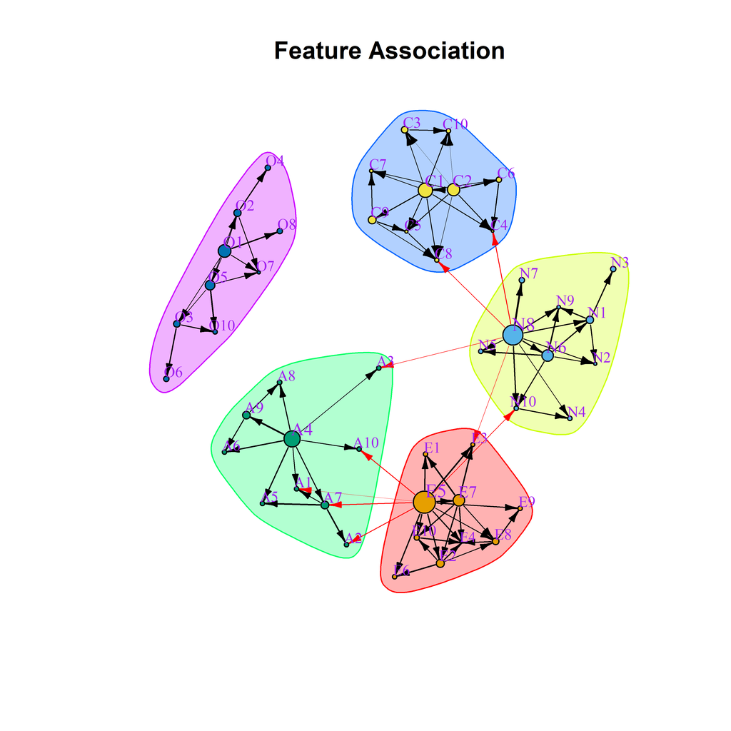

```r
par(op)

  transform <- attr(trainage_DE,"UPLTM") != 0
  colnames(transform) <- str_remove_all(colnames(transform),"La_")
  transform <- abs(transform*cor(trainingset[,rownames(transform)])) # The weights are proportional to the observed correlation


  VertexSize <- attr(trainage_DE,"fscore") # The size depends on the variable independence relevance (fscore)
  names(VertexSize) <- str_remove_all(names(VertexSize),"La_")
  VertexSize <- 0.5+9.5*(VertexSize-min(VertexSize))/(max(VertexSize)-min(VertexSize)) # Normalization
  VertexSize <- VertexSize[colnames(transform)]
  gr <- graph_from_adjacency_matrix(transform,mode = "directed",diag = FALSE,weighted=TRUE)
  gr$layout <- layout_with_fr

  fc <- cluster_optimal(gr)
  plot(fc, gr,
       edge.width = 2*E(gr)$weight,
       vertex.size=VertexSize,
       edge.arrow.size=0.5,
       edge.arrow.width=0.75,
       vertex.label.color="purple",
#       vertex.label.cex=0.85,
#       vertex.label.dist=1.2,
       vertex.label.cex=(0.70 + 0.025*VertexSize),
       vertex.label.dist=(0.5 + 0.05*VertexSize),


       main="Feature Association")
```

```r
par(op)

      varratios <- attr(trainage_DE,"VarRatio")
      names(varratios) <- str_remove_all(names(varratios),"La_")
      fscores <- attr(trainage_DE,"fscore")
      names(fscores) <- str_remove_all(names(fscores),"La_")
      clustable <- as.data.frame(cbind(Variable=fc$names,
                                       Formula=as.character(theCharformulas[paste("La_",fc$names,sep="")]),
                                       Cluster=fc$membership,
                                       ResidualVariance=round(varratios[fc$names],3),
                                       Fscore=round(fscores[fc$names],3)
                                       )
                                 )
      rownames(clustable) <- str_replace_all(rownames(clustable),"__","_")
      clustable$Variable <- NULL
      clustable$Cluster <- as.integer(clustable$Cluster)
      clustable$ResidualVariance <- as.numeric(clustable$ResidualVariance)
      clustable$Fscore <- as.numeric(clustable$Fscore)
      clustable <- clustable[order(-clustable$Fscore),]
      clustable <- clustable[order(-clustable$ResidualVariance),]
      clustable <- clustable[order(clustable$Cluster),]

pander::pander(as.matrix(clustable))
```

|  | Formula | Cluster | ResidualVariance | Fscore |
| --- | --- | --- | --- | --- |
| **E5** | NA | 1 | 1.000 | 13.000 |
| **E8** | - (0.230)E2 + (0.259)E5 - (0.050)E7 + E8 | 1 | 0.834 | 0.000 |
| **E9** | - (0.250)E5 + (0.574)E8 + E9 | 1 | 0.676 | -2.000 |
| **E2** | + E2 + (0.403)E5 + (0.217)E7 | 1 | 0.671 | 1.082 |
| **E6** | - (0.409)E2 + (0.237)E5 + E6 | 1 | 0.634 | -2.000 |
| **E10** | - (0.016)E2 + (0.347)E5 + (0.290)E7 + E10 | 1 | 0.633 | -1.164 |
| **E1** | + E1 - (0.175)E5 - (0.412)E7 | 1 | 0.630 | -2.000 |
| **E7** | - (0.705)E5 + E7 | 1 | 0.599 | 4.000 |
| **E3** | + E3 - (0.356)E5 - (0.300)E7 + (0.034)N8 | 1 | 0.569 | -2.238 |
| **E4** | - (0.297)E2 + E4 + (0.068)E5 + (0.145)E7 - (0.177)E8 - (0.175)E10 | 1 | 0.557 | -4.918 |
| **N8** | NA | 2 | 1.000 | 11.238 |
| **N4** | + N4 + (0.048)N8 + (0.346)N10 | 2 | 0.837 | -2.000 |
| **N5** | + N5 - (0.372)N6 - (0.176)N8 | 2 | 0.740 | -2.000 |
| **N2** | + (0.318)N1 + N2 + (0.137)N6 + (0.084)N8 | 2 | 0.738 | -3.000 |
| **N6** | + N6 - (0.525)N8 | 2 | 0.712 | 4.000 |
| **N3** | - (0.488)N1 + N3 | 2 | 0.688 | -1.000 |
| **N1** | + N1 - (0.424)N6 - (0.198)N8 | 2 | 0.683 | 0.645 |
| **N10** | + (0.173)E5 - (0.222)N6 - (0.409)N8 + N10 | 2 | 0.645 | -2.000 |
| **N9** | - (0.120)N1 - (0.547)N6 - (0.174)N8 + N9 | 2 | 0.568 | -2.645 |
| **N7** | + N7 - (0.738)N8 | 2 | 0.411 | -1.000 |
| **A4** | NA | 3 | 1.000 | 8.000 |
| **A3** | - (0.179)N8 + A3 + (0.362)A4 | 3 | 0.864 | -2.000 |
| **A1** | - (0.073)E5 + A1 + (0.285)A4 - (0.308)A7 | 3 | 0.843 | -2.000 |
| **A10** | - (0.322)E5 - (0.251)A4 + A10 | 3 | 0.784 | -2.000 |
| **A8** | - (0.337)A4 + A8 - (0.190)A9 | 3 | 0.751 | -1.832 |
| **A7** | + (0.238)E5 + (0.480)A4 + A7 | 3 | 0.729 | 1.000 |
| **A6** | - (0.362)A4 + A6 - (0.268)A9 | 3 | 0.709 | -2.000 |
| **A2** | - (0.144)E5 + A2 + (0.552)A7 | 3 | 0.632 | -2.000 |
| **A5** | + (0.276)A4 + A5 - (0.573)A7 | 3 | 0.614 | -2.000 |
| **A9** | - (0.682)A4 + A9 | 3 | 0.571 | 0.832 |
| **C2** | NA | 4 | 1.000 | 4.684 |
| **C1** | + C1 + (0.210)C2 | 4 | 0.931 | 6.398 |
| **C3** | - (0.271)C1 - (8.71e-03)C2 + C3 | 4 | 0.911 | 0.000 |
| **C8** | - (0.187)N8 + (0.335)C1 + (1.51e-04)C2 + (7.77e-04)C5 + C8 + (4.85e-04)C9 | 4 | 0.844 | -2.008 |
| **C10** | - (0.226)C1 - (6.97e-03)C2 - (0.284)C3 + C10 | 4 | 0.826 | -2.000 |
| **C9** | - (0.484)C1 + C9 | 4 | 0.819 | 1.004 |
| **C7** | - (0.142)C1 + (0.080)C2 + C7 - (0.298)C9 | 4 | 0.809 | -2.684 |
| **C5** | - (0.289)C1 + (0.195)C2 + C5 - (0.314)C9 | 4 | 0.724 | -2.996 |
| **C6** | + (0.244)C1 - (0.472)C2 + C6 | 4 | 0.702 | -1.000 |
| **C4** | - (0.252)N8 + (0.077)C1 - (0.201)C2 + C4 - (0.280)C6 | 4 | 0.666 | -3.398 |
| **O1** | NA | 5 | 1.000 | 5.023 |
| **O5** | - (0.260)O1 + O5 | 5 | 0.905 | 2.477 |
| **O3** | - (0.153)O1 + O3 - (0.261)O5 | 5 | 0.886 | 0.000 |
| **O2** | + (0.300)O1 + O2 + (0.115)O5 | 5 | 0.869 | 0.523 |
| **O7** | - (0.148)O1 + (0.186)O2 - (0.288)O5 + O7 | 5 | 0.747 | -3.000 |
| **O6** | + (0.563)O3 + O6 | 5 | 0.720 | -1.000 |
| **O4** | - (0.521)O2 + O4 | 5 | 0.715 | -1.000 |
| **O8** | - (0.710)O1 + O8 | 5 | 0.605 | -1.000 |
| **O10** | - (0.242)O3 - (0.652)O5 + O10 | 5 | 0.552 | -2.000 |

### 1.4.8 Correlation Matrix of the Data

The heat map of the ILAA transformed data

```r
par(op)

varlistDe <- colnames(trainage_DE)
varlistDe <- varlistDe[varlistDe != outcome]

  par(cex=0.6,cex.main=0.85,cex.axis=0.7)

# Training
  cormat <- cor(trainage_DE[,varlistDe],method="pearson")
  cormat[is.na(cormat)] <- 0
  gplots::heatmap.2(abs(cormat),
                    trace = "none",
                    mar = c(5,5),
                    col=rev(heat.colors(5)),
                    main = "Training: After ILAA Correlation",
                    cexRow = cexheat,
                    cexCol = cexheat,
                     srtCol=45,
                     srtRow=45,
                    key.title=NA,
                    key.xlab="|Pearson Correlation|",
                    xlab="Feature", ylab="Feature")
  diag(cormat) <- 0
  pander::pander(max(abs(cormat)))
```

*0.198*

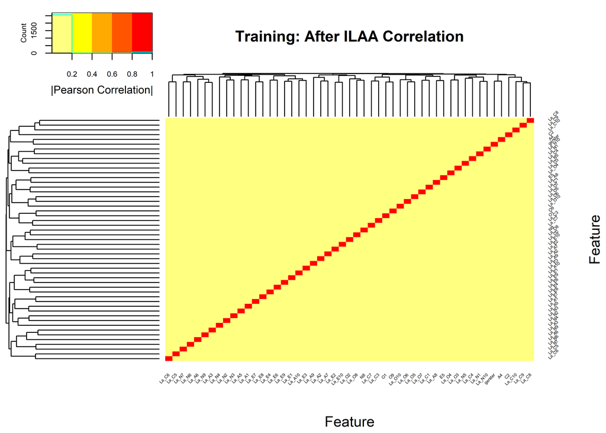

```r
  par(op)
```

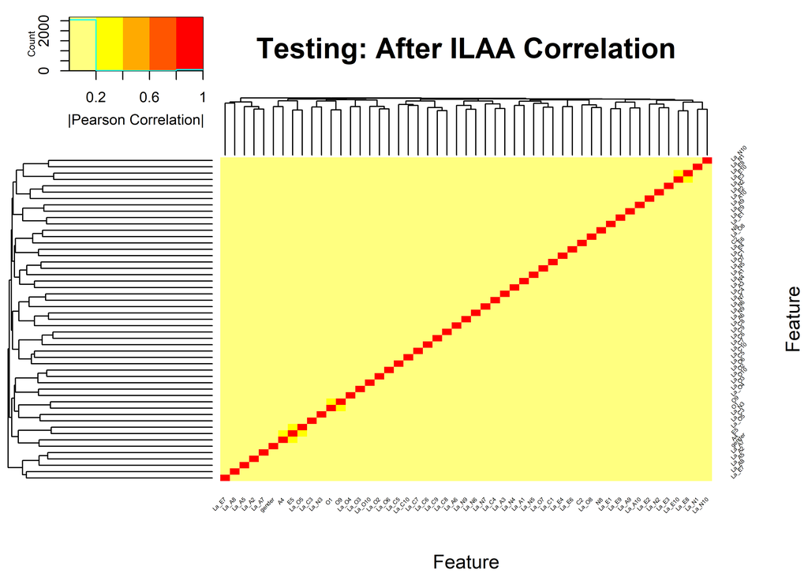

```r
# Testing

  cormat <- cor(testage_DE[,varlistDe],method="pearson")
  cormat[is.na(cormat)] <- 0
  gplots::heatmap.2(abs(cormat),
                    trace = "none",
                    mar = c(5,5),
                    col=rev(heat.colors(5)),
                    main = "Testing: After ILAA Correlation",
                    cexRow = cexheat,
                    cexCol = cexheat,
                     srtCol=45,
                     srtRow=45,
                    key.title=NA,
                    key.xlab="|Pearson Correlation|",
                    xlab="Feature", ylab="Feature")
```

```r
  diag(cormat) <- 0
  pander::pander(max(abs(cormat)))
```

*0.213*

```r
  par(op)
```

### 1.4.9 Modeling

#### 1.4.9.1 Modeling outcome using raw set

```r
outcomeModel <- LASSO_1SE(formula(paste(outcome,"~.")),trainingset);
predOutcome <- predict(outcomeModel,testingset)
pander::pander(as.matrix(outcomeModel$coef))
```

| **(Intercept)** | 1.483869 |
| --- | --- |
| **gender** | 0.020497 |
| **E1** | -0.000793 |
| **E2** | 0.002568 |
| **E5** | 0.004998 |
| **E6** | -0.003737 |
| **E9** | -0.008185 |
| **E10** | -0.012682 |
| **N1** | -0.005191 |
| **N2** | -0.014562 |
| **N3** | -0.006960 |
| **N5** | 0.002689 |
| **N6** | 0.000923 |
| **N7** | -0.012670 |
| **N10** | 0.003161 |
| **A1** | -0.007726 |
| **A2** | -0.000213 |
| **A3** | -0.012584 |
| **A4** | 0.001779 |
| **A5** | 0.005324 |
| **A6** | 0.008162 |
| **A7** | 0.002342 |
| **A8** | -0.001047 |
| **A10** | 0.006571 |
| **C1** | -0.003545 |
| **C2** | 0.005909 |
| **C3** | -0.007768 |
| **C4** | -0.009452 |
| **C5** | 0.004839 |
| **C6** | -0.004175 |
| **C7** | 0.003688 |
| **C8** | -0.019641 |
| **C10** | 0.005771 |
| **O1** | 0.011377 |
| **O3** | -0.001174 |
| **O4** | 0.003396 |
| **O5** | 0.010032 |
| **O7** | 0.001588 |
| **O8** | -0.000314 |
| **O9** | 0.006821 |
| **O10** | -0.005317 |

#### 1.4.9.2 Modeling outcome using decorrelated set

```r
outcomeModel_DE <- LASSO_1SE(formula(paste(outcome,"~.")),trainage_DE);
predOutcome_DE <- predict(outcomeModel_DE,testage_DE)

pander::pander(as.matrix(outcomeModel_DE$coef),caption="ILAA Coef")
```

ILAA Coef

| **(Intercept)** | 1.510622 |
| --- | --- |
| **gender** | 0.018330 |
| **La_E1** | -0.001084 |
| **La_E2** | 0.002435 |
| **E5** | 0.008529 |
| **La_E6** | -0.003784 |
| **La_E8** | 0.001371 |
| **La_E9** | -0.007292 |
| **La_E10** | -0.011387 |
| **La_N1** | -0.003824 |
| **La_N2** | -0.014104 |
| **La_N3** | -0.004829 |
| **La_N5** | 0.001339 |
| **La_N6** | 0.001581 |
| **La_N7** | -0.014789 |
| **N8** | -0.011644 |
| **La_N9** | -0.001111 |
| **La_N10** | 0.001719 |
| **La_A1** | -0.007829 |
| **La_A3** | -0.011671 |
| **A4** | 0.010280 |
| **La_A5** | 0.004601 |
| **La_A6** | 0.006600 |
| **La_A7** | 0.003458 |
| **La_A8** | -0.000340 |
| **La_A10** | 0.005629 |
| **La_C1** | 0.004793 |
| **La_C3** | -0.003951 |
| **La_C4** | -0.009332 |
| **La_C5** | 0.005076 |
| **La_C6** | -0.007835 |
| **La_C7** | 0.003530 |
| **La_C8** | -0.019915 |
| **La_C9** | 0.000435 |
| **La_C10** | 0.007418 |
| **O1** | 0.011554 |
| **La_O2** | 0.000173 |
| **La_O3** | -0.003764 |
| **La_O4** | 0.002166 |
| **La_O5** | 0.005263 |
| **La_O7** | 0.000840 |
| **La_O8** | -0.002637 |
| **O9** | 0.006231 |
| **La_O10** | -0.006809 |

```r
obsCoef <- getObservedCoef(trainage_DE,outcomeModel_DE)
pander::pander(as.matrix(obsCoef$coef),caption="ILAA Modeling")
```

ILAA Modeling

| **(Intercept)** | 1.510622 |
| --- | --- |
| **gender** | 0.018330 |
| **O9** | 0.006231 |
| **E1** | -0.001084 |
| **E2** | 0.003849 |
| **E5** | 0.006918 |
| **E6** | -0.003784 |
| **E7** | -0.002394 |
| **E8** | -0.002818 |
| **E9** | -0.007292 |
| **E10** | -0.011387 |
| **N1** | -0.005822 |
| **N2** | -0.014104 |
| **N3** | -0.004829 |
| **N5** | 0.001339 |
| **N6** | 0.000998 |
| **N7** | -0.014789 |
| **N8** | 0.005420 |
| **N9** | -0.001111 |
| **N10** | 0.001719 |
| **A1** | -0.007829 |
| **A3** | -0.011671 |
| **A4** | 0.003067 |
| **A5** | 0.004601 |
| **A6** | 0.006600 |
| **A7** | 0.003228 |
| **A8** | -0.000340 |
| **A9** | -0.001705 |
| **A10** | 0.005629 |
| **C1** | -0.007295 |
| **C2** | 0.007837 |
| **C3** | -0.006058 |
| **C4** | -0.009332 |
| **C5** | 0.005060 |
| **C6** | -0.005226 |
| **C7** | 0.003530 |
| **C8** | -0.019915 |
| **C9** | -0.002224 |
| **C10** | 0.007418 |
| **O1** | 0.012563 |
| **O2** | -0.000798 |
| **O3** | -0.002116 |
| **O4** | 0.002166 |
| **O5** | 0.010458 |
| **O7** | 0.000840 |
| **O8** | -0.002637 |
| **O10** | -0.006809 |

```r
pander::pander(cor.test(predOutcome,testingset[,outcome]),caption="Raw Model")
```

Raw Model

| Test statistic | df | P value | Alternative hypothesis | cor |
| --- | --- | --- | --- | --- |
| 33.7 | 4824 | 2.05e-223 * * * | two.sided | 0.436 |

```r
pander::pander(cor.test(predOutcome_DE,testage_DE[,outcome]),caption="ILAA-based Model")
```

ILAA-based Model

| Test statistic | df | P value | Alternative hypothesis | cor |
| --- | --- | --- | --- | --- |
| 33.8 | 4824 | 1.54e-224 * * * | two.sided | 0.437 |

#### 1.4.9.3 Univariate t-test

```r
rawunittvalues <- apply(as.matrix(testingset[,names(outcomeModel$coef)[-1]]),2,tvals,testingset[,outcome])
names(rawunittvalues) <- names(outcomeModel$coef)[-1]

deunittvalues <- apply(testage_DE[,names(outcomeModel_DE$coef)[-1]],2,tvals,testingset[,outcome])
```

#### 1.4.9.4 Comparing summaries

```r
psig <- 0.1/(ncol(testingset)-1)
lmod <- lm(paste(outcome,"~."),testingset[,c(outcome,names(outcomeModel$coef)[-1])])
try(vifx <-vif(lm(paste(outcome,"~."),testingset[,c(outcome,names(outcomeModel$coef)[-1])])))
sm <- summary(lmod)
if (length(lmod$coef)>10)
{
  sm$coefficients[1,4] <- 1.0
  gcoef <- lmod$coef[sm$coefficients[,4]<psig]
  lmod <- lm(paste(outcome,"~."),testingset[,c(outcome,names(gcoef))])
  try(vifx <-vif(lm(paste(outcome,"~."),testingset[,c(outcome,names(gcoef))])))
}



sm <- summary(lmod)
smcoef <- as.data.frame(sm$coefficients)
smcoef <- smcoef[order(-abs(smcoef[,3])),]
smcoef$Uni_t_values <- rawunittvalues[rownames(smcoef)]
if (!inherits(vif,"try-error")) smcoef$vif <-vifx[rownames(smcoef)]
smcoef <- smcoef[!is.na(smcoef$Uni_t_values),]
if (nrow(smcoef)>10) smcoef <- smcoef[smcoef[,4]<psig,]

pander::pander(smcoef)
```

|  | Estimate | Std. Error | t value | Pr(>\|t\|) | Uni_t_values | vif |
| --- | --- | --- | --- | --- | --- | --- |
| **O1** | 0.02304 | 0.00265 | 8.69 | 4.87e-18 | 9.467 | 1.84 |
| **C8** | -0.01862 | 0.00225 | -8.28 | 1.56e-16 | -18.654 | 1.37 |
| **A3** | -0.01653 | 0.00202 | -8.17 | 3.83e-16 | -14.764 | 1.25 |
| **N2** | -0.01588 | 0.00216 | -7.34 | 2.58e-13 | -1.496 | 1.36 |
| **N7** | -0.01449 | 0.00208 | -6.95 | 4.00e-12 | -14.874 | 1.56 |
| **E10** | -0.01386 | 0.00210 | -6.60 | 4.49e-11 | -11.288 | 1.54 |
| **A1** | -0.01121 | 0.00174 | -6.44 | 1.30e-10 | -10.467 | 1.21 |
| **C4** | -0.01272 | 0.00220 | -5.78 | 7.95e-09 | -16.127 | 1.57 |
| **A7** | 0.01113 | 0.00226 | 4.92 | 8.75e-07 | -4.492 | 1.40 |
| **gender** | 0.02249 | 0.00471 | 4.77 | 1.87e-06 | 2.235 | 1.11 |
| **C5** | 0.00950 | 0.00204 | 4.66 | 3.23e-06 | 12.496 | 1.36 |
| **O8** | -0.01088 | 0.00235 | -4.63 | 3.77e-06 | -0.140 | 1.84 |
| **E5** | 0.01025 | 0.00222 | 4.63 | 3.81e-06 | 9.291 | 1.66 |
| **C10** | 0.01069 | 0.00237 | 4.51 | 6.50e-06 | 10.096 | 1.23 |
| **E9** | -0.00811 | 0.00181 | -4.48 | 7.74e-06 | 0.599 | 1.35 |
| **N6** | 0.00945 | 0.00225 | 4.20 | 2.76e-05 | -6.137 | 1.87 |
| **N3** | -0.00974 | 0.00249 | -3.91 | 9.26e-05 | -8.653 | 1.67 |
| **N5** | 0.00765 | 0.00202 | 3.78 | 1.56e-04 | -4.218 | 1.38 |
| **N1** | -0.00842 | 0.00225 | -3.74 | 1.88e-04 | -8.452 | 1.83 |
| **O9** | 0.00871 | 0.00234 | 3.73 | 1.93e-04 | 3.492 | 1.13 |
| **C3** | -0.00860 | 0.00238 | -3.61 | 3.06e-04 | 2.279 | 1.23 |
| **C2** | 0.00633 | 0.00183 | 3.46 | 5.40e-04 | -5.052 | 1.31 |

```r
pander::pander(t(c(R2=sm$r.squared,adj_R2=sm$adj.r.squared)))
```

| R2 | adj_R2 |
| --- | --- |
| 0.188 | 0.185 |

```r
pander::pander(c(numvar=nrow(smcoef)))
```

| numvar |
| --- |
| 22 |

```r
lmod_DE <- lm(paste(outcome,"~."),testage_DE[,c(outcome,names(outcomeModel_DE$coef)[-1])])
try(vifx <-vif(lm(paste(outcome,"~."),testage_DE[,c(outcome,names(outcomeModel_DE$coef)[-1])])))

sm <- summary(lmod_DE)
if (length(lmod_DE$coef)>10)
{
  sm$coefficients[1,4] <- 1.0
  gcoef <- lmod_DE$coef[sm$coefficients[,4]<psig]
  lmod_DE <- lm(paste(outcome,"~."),testage_DE[,c(outcome,names(gcoef))])
  try(vifx <-vif(lm(paste(outcome,"~."),testage_DE[,c(outcome,names(gcoef))])))
}

sm <- summary(lmod_DE)
lacoef <- as.data.frame(sm$coefficients)
lacoef <- lacoef[order(-abs(lacoef[,3])),]
lacoef$Uni_t_values <- deunittvalues[rownames(lacoef)]
if (!inherits(vif,"try-error")) lacoef$vif <-vifx[rownames(lacoef)]
lacoef <- lacoef[!is.na(lacoef$Uni_t_values),]
if (nrow(lacoef)>10) lacoef <- lacoef[lacoef[,4]<psig,]

lacoef$formula <- theCharformulas[rownames(lacoef)]
lacoef$VarRatio <- varratios[str_remove_all(rownames(lacoef),"La_")]

pander::pander(lacoef)
```

|  | Estimate | Std. Error | t value | Pr(>\|t\|) | Uni_t_values | vif | formula | VarRatio |
| --- | --- | --- | --- | --- | --- | --- | --- | --- |
| **La_C8** | -0.02000 | 0.00223 | -8.96 | 4.46e-19 | -14.673 | 1.17 | - (0.187)N8 + (0.335)C1 + (1.51e-04)C2 + (7.77e-04)C5 + C8 + (4.85e-04)C9 | 0.844 |
| **La_A3** | -0.01647 | 0.00206 | -7.99 | 1.69e-15 | -11.043 | 1.13 | - (0.179)N8 + A3 + (0.362)A4 | 0.864 |
| **La_N7** | -0.02101 | 0.00267 | -7.86 | 4.56e-15 | -10.016 | 1.05 | + N7 - (0.738)N8 | 0.411 |
| **La_N2** | -0.01655 | 0.00216 | -7.66 | 2.18e-14 | -7.312 | 1.08 | + (0.318)N1 + N2 + (0.137)N6 + (0.084)N8 | 0.738 |
| **O1** | 0.01410 | 0.00204 | 6.91 | 5.67e-12 | 9.467 | 1.10 | NA | 1.000 |
| **La_E10** | -0.01393 | 0.00218 | -6.40 | 1.70e-10 | -7.492 | 1.10 | - (0.016)E2 + (0.347)E5 + (0.290)E7 + E10 | 0.633 |
| **La_A1** | -0.01103 | 0.00178 | -6.20 | 6.29e-10 | -9.185 | 1.07 | - (0.073)E5 + A1 + (0.285)A4 - (0.308)A7 | 0.843 |
| **E5** | 0.01096 | 0.00182 | 6.03 | 1.75e-09 | 9.291 | 1.12 | NA | 1.000 |
| **N8** | -0.01034 | 0.00173 | -5.99 | 2.30e-09 | -10.878 | 1.16 | NA | 1.000 |
| **La_C4** | -0.01183 | 0.00225 | -5.27 | 1.45e-07 | -9.343 | 1.12 | - (0.252)N8 + (0.077)C1 - (0.201)C2 + C4 - (0.280)C6 | 0.666 |
| **La_O8** | -0.01198 | 0.00234 | -5.12 | 3.19e-07 | -7.981 | 1.07 | - (0.710)O1 + O8 | 0.605 |
| **La_C10** | 0.01212 | 0.00238 | 5.10 | 3.55e-07 | 8.436 | 1.05 | - (0.226)C1 - (6.97e-03)C2 - (0.284)C3 + C10 | 0.826 |
| **La_C6** | -0.00954 | 0.00190 | -5.02 | 5.25e-07 | -8.754 | 1.09 | + (0.244)C1 - (0.472)C2 + C6 | 0.702 |
| **La_A7** | 0.01168 | 0.00233 | 5.02 | 5.34e-07 | 1.120 | 1.11 | + (0.238)E5 + (0.480)A4 + A7 | 0.729 |
| **gender** | 0.02064 | 0.00469 | 4.40 | 1.10e-05 | 2.235 | 1.11 | NA | 1.000 |
| **La_N3** | -0.01062 | 0.00246 | -4.31 | 1.64e-05 | -4.584 | 1.16 | - (0.488)N1 + N3 | 0.688 |
| **A4** | 0.00948 | 0.00222 | 4.26 | 2.05e-05 | 6.858 | 1.15 | NA | 1.000 |
| **La_N6** | 0.00858 | 0.00207 | 4.14 | 3.54e-05 | -0.403 | 1.11 | + N6 - (0.525)N8 | 0.712 |
| **La_C5** | 0.00877 | 0.00214 | 4.11 | 4.08e-05 | 8.188 | 1.09 | - (0.289)C1 + (0.195)C2 + C5 - (0.314)C9 | 0.724 |
| **La_C1** | 0.00851 | 0.00214 | 3.97 | 7.23e-05 | 5.979 | 1.10 | + C1 + (0.210)C2 | 0.931 |
| **La_N1** | -0.00755 | 0.00209 | -3.61 | 3.10e-04 | -4.306 | 1.09 | + N1 - (0.424)N6 - (0.198)N8 | 0.683 |
| **La_E8** | 0.00681 | 0.00190 | 3.58 | 3.45e-04 | 3.430 | 1.08 | - (0.230)E2 + (0.259)E5 - (0.050)E7 + E8 | 0.834 |
| **La_A5** | 0.00879 | 0.00248 | 3.55 | 3.95e-04 | 1.233 | 1.07 | + (0.276)A4 + A5 - (0.573)A7 | 0.614 |
| **O9** | 0.00767 | 0.00233 | 3.29 | 1.03e-03 | 3.492 | 1.13 | NA | 1.000 |

```r
pander::pander(t(c(R2=sm$r.squared,adj_R2=sm$adj.r.squared)))
```

| R2 | adj_R2 |
| --- | --- |
| 0.192 | 0.188 |

```r
pander::pander(c(numvar=nrow(lacoef)))
```

| numvar |
| --- |
| 24 |

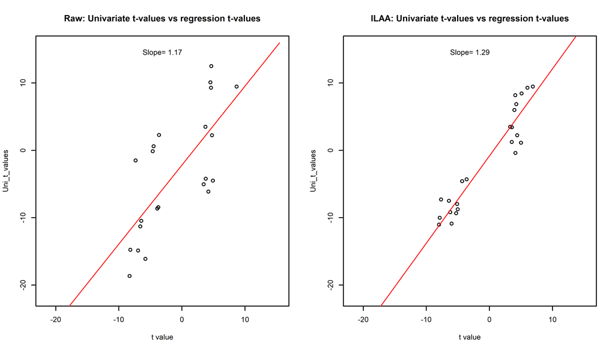

```r
xvals <-c(min(c(deunittvalues,rawunittvalues))-3,max(c(deunittvalues,rawunittvalues))+3)

par(mfrow=c(1,2),cex=0.5)

plot(smcoef[,c(3,5)],
     main="Raw: Univariate t-values vs regression t-values",
     xlim=xvals,
     ylim=xvals
     )

lmtvals <- lm(smcoef[,5]~smcoef[,3])
pred <- lmtvals$coefficients[1] + lmtvals$coefficients[2] * xvals
lines(x=xvals,y=pred,col="red")
text(xvals[1]+(xvals[2]-xvals[1])/2,xvals[2]-1,sprintf("Slope= %.2f",lmtvals$coefficients[2]))


plot(lacoef[-1,c(3,5)],
     main="ILAA: Univariate t-values vs regression t-values",
     xlim=xvals,
     ylim=xvals
     )

lmtvals <- lm(lacoef[,5]~lacoef[,3])
pred <- lmtvals$coefficients[1] + lmtvals$coefficients[2] * xvals
lines(x=xvals,y=pred,col="red")
text(xvals[1]+(xvals[2]-xvals[1])/2,xvals[2]-1,sprintf("Slope= %.2f",lmtvals$coefficients[2]))
```

```r
#pander::pander(summary(lmtvals))


pander::pander(cor.test(smcoef[,3],smcoef[,5]))
```

Pearson’s product-moment correlation: `smcoef[, 3]` and `smcoef[, 5]`

| Test statistic | df | P value | Alternative hypothesis | cor |
| --- | --- | --- | --- | --- |
| 4.68 | 20 | 0.000143 * * * | two.sided | 0.723 |

```r
pander::pander(cor.test(lacoef[,3],lacoef[,5]))
```

Pearson’s product-moment correlation: `lacoef[, 3]` and `lacoef[, 5]`

| Test statistic | df | P value | Alternative hypothesis | cor |
| --- | --- | --- | --- | --- |
| 14.4 | 22 | 1.08e-12 * * * | two.sided | 0.951 |

```r
par(op)
```

#### 1.4.9.5 Ploting predictions

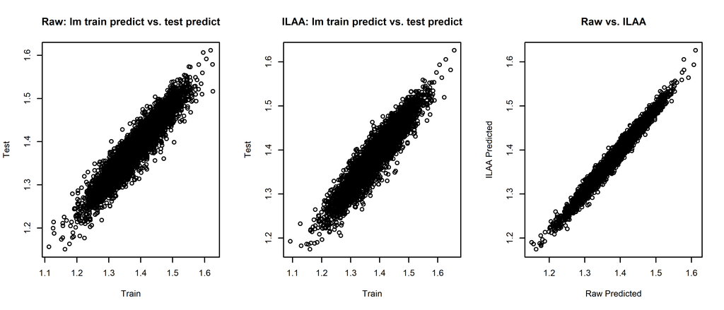

```r
par(mfrow=c(1,3),cex=0.5)
plot(lmod$fitted.values,predOutcome,main="Raw: lm train predict vs. test predict",xlab="Train",ylab="Test")
plot(lmod_DE$fitted.values,predOutcome_DE,main="ILAA: lm train predict vs. test predict",xlab="Train",ylab="Test")

plot(predOutcome,predOutcome_DE,xlab="Raw Predicted",ylab="ILAA Predicted",main="Raw vs. ILAA")
```

```r
par(op)
```

### 1.4.10 CV

#### 1.4.10.1 test Correlations

```r
par(op)
corresults <- CV_IDeA(dataframe,outcome,loops=loops)
```

………. ………. ……….

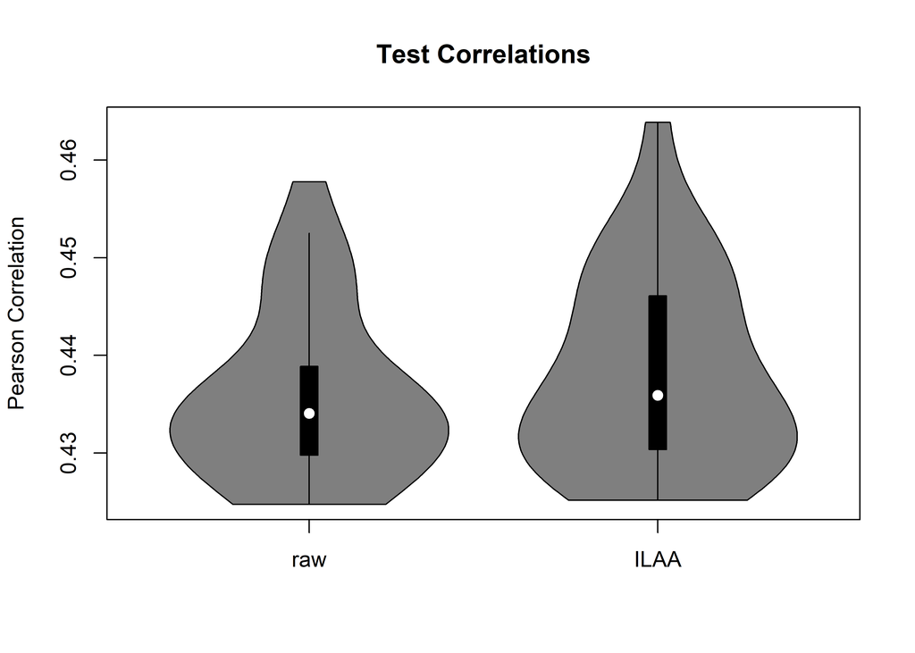

```r
mintvals <- min(c(min(corresults$rawtValues),min(corresults$detValues)))
maxvals <- max(c(max(corresults$rawtValues),max(corresults$detValues)))
xvals <- c(mintvals,maxvals)

vioplot(list(raw=corresults$testRawCorrelations,ILAA=corresults$testDeCorrelations),
        ylab="Pearson Correlation",
        main="Test Correlations")
```

```r
pander::pander(t.test(corresults$testDeCorrelations,corresults$testRawCorrelations,paired=TRUE))
```

Paired t-test: `corresults$testDeCorrelations` and `corresults$testRawCorrelations`

| Test statistic | df | P value | Alternative hypothesis | mean difference |
| --- | --- | --- | --- | --- |
| 3.09 | 29 | 0.00439 * * | two.sided | 0.00224 |

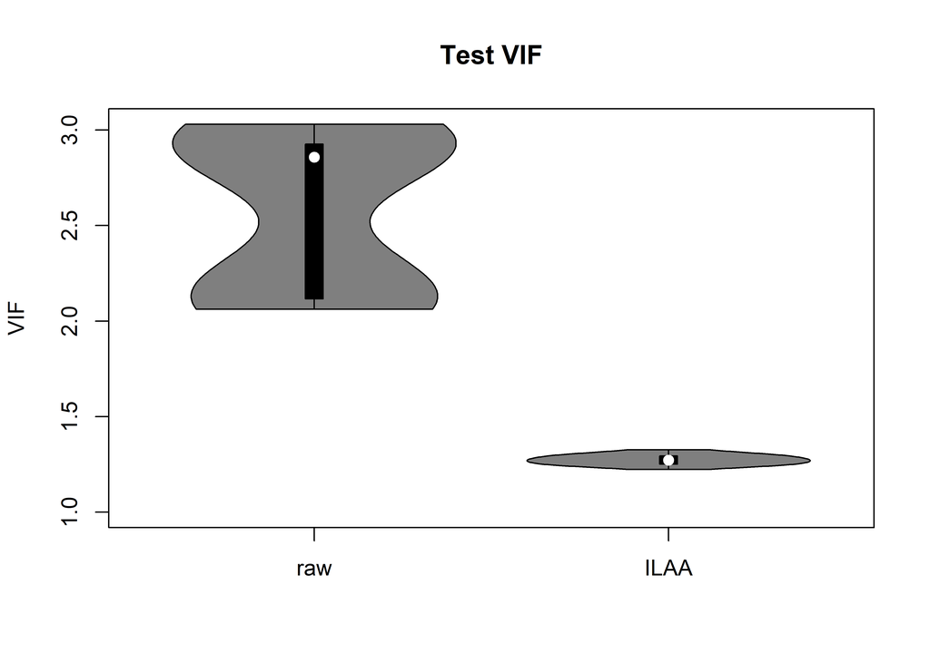

```r
sylim <- c(1,min(c(20,max(corresults$VIFRaw))))
vioplot(list(raw=corresults$VIFRaw,ILAA=corresults$VIFDe),
        ylab="VIF",
        ylim=sylim,
        main="Test VIF")
```

```r
pander::pander(summary(cbind(raw=corresults$VIFRaw,ILAA=corresults$VIFDe)))
```

| raw | ILAA |
| --- | --- |
| Min. :2.062 | Min. :1.224 |
| 1st Qu.:2.116 | 1st Qu.:1.251 |
| Median :2.858 | Median :1.272 |
| Mean :2.559 | Mean :1.275 |
| 3rd Qu.:2.926 | 3rd Qu.:1.294 |
| Max. :3.030 | Max. :1.326 |

```r
summary(corresults$VIFRaw)
```

Min. 1st Qu. Median Mean 3rd Qu. Max. 2.062 2.116 2.858 2.559 2.926 3.030

### 1.4.11 The t-values

```r
par(op)
par(mfrow=c(1,2),cex=0.5)
plot(corresults$rawtValues,
     main="Raw: Univariate t-values vs Model t-values",
     xlab="Univariate",
     ylab="Model",
     xlim=xvals,
     ylim=xvals)

lmtvals <- lm(Model~.,corresults$rawtValues)
pred <- lmtvals$coefficients[1] + lmtvals$coefficients[2] * xvals
lines(x=xvals,y=pred,col="red")
text(xvals[1]+(xvals[2]-xvals[1])/2,xvals[2]-1,sprintf("Slope= %.2f",lmtvals$coefficients[2]))

pander::pander(summary(lmtvals))
```

|  | Estimate | Std. Error | t value | Pr(>\|t\|) |
| --- | --- | --- | --- | --- |
| **(Intercept)** | 0.123 | 0.0931 | 1.32 | 1.87e-01 |
| **Uni** | 0.311 | 0.0111 | 27.94 | 1.92e-133 |

Fitting linear model: Model ~ .

| Observations | Residual Std. Error | $R^2$ | Adjusted $R^2$ |
| --- | --- | --- | --- |
| 1234 | 3.21 | 0.388 | 0.387 |

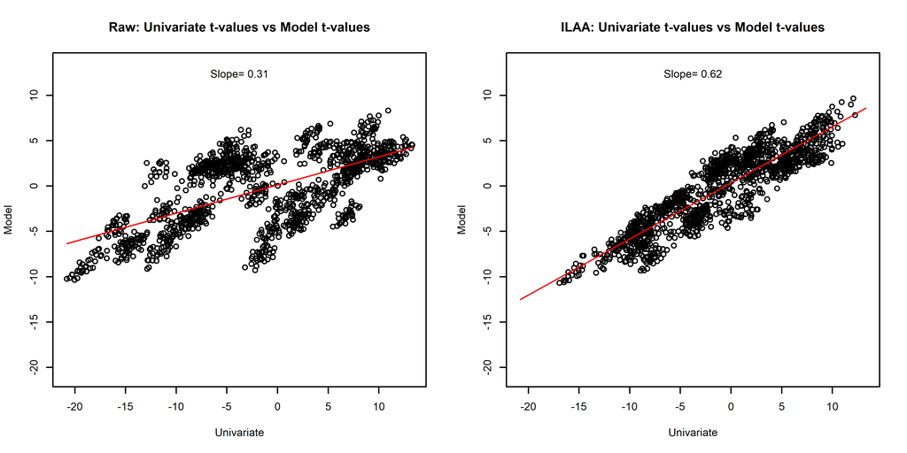

```r
plot(corresults$detValues,
      main="ILAA: Univariate t-values vs Model t-values",
     xlab="Univariate",
     ylab="Model",
     xlim=xvals,
     ylim=xvals)

lmtvals <- lm(Model~.,corresults$detValues)
pred <- lmtvals$coefficients[1] + lmtvals$coefficients[2] * xvals
lines(x=xvals,y=pred,col="red")
text(xvals[1]+(xvals[2]-xvals[1])/2,xvals[2]-1,sprintf("Slope= %.2f",lmtvals$coefficients[2]))
```

```r
pander::pander(summary(lmtvals))
```

|  | Estimate | Std. Error | t value | Pr(>\|t\|) |
| --- | --- | --- | --- | --- |
| **(Intercept)** | 0.355 | 0.05328 | 6.67 | 3.83e-11 |
| **Uni** | 0.619 | 0.00839 | 73.73 | 0.00e+00 |

Fitting linear model: Model ~ .

| Observations | Residual Std. Error | $R^2$ | Adjusted $R^2$ |
| --- | --- | --- | --- |
| 1263 | 1.86 | 0.812 | 0.812 |

### 1.4.12 The age plots

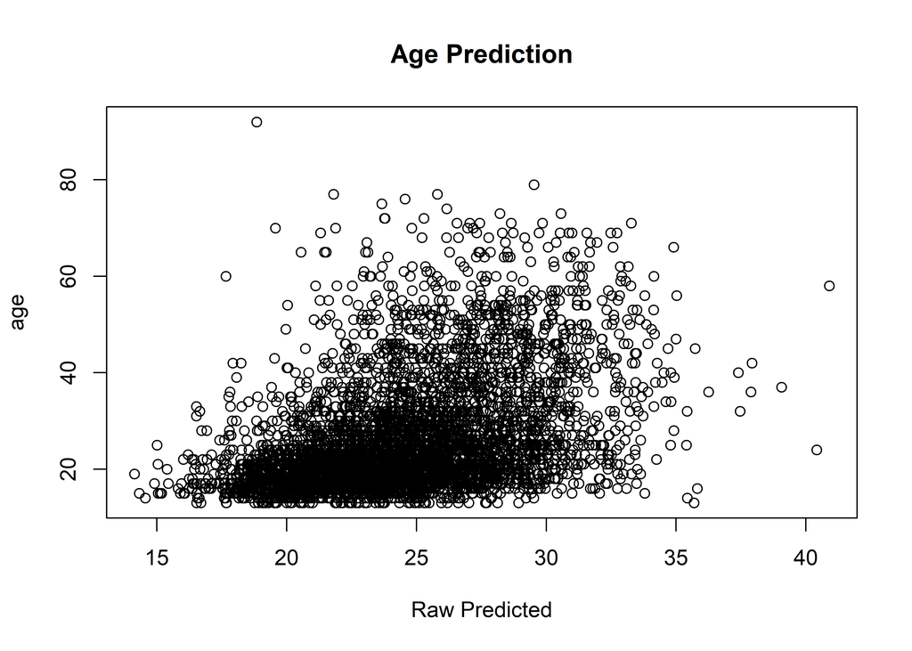

```r
plot(10^predOutcome,10^testingset[,outcome],xlab="Raw Predicted",ylab=outcome,main="Age Prediction")
```

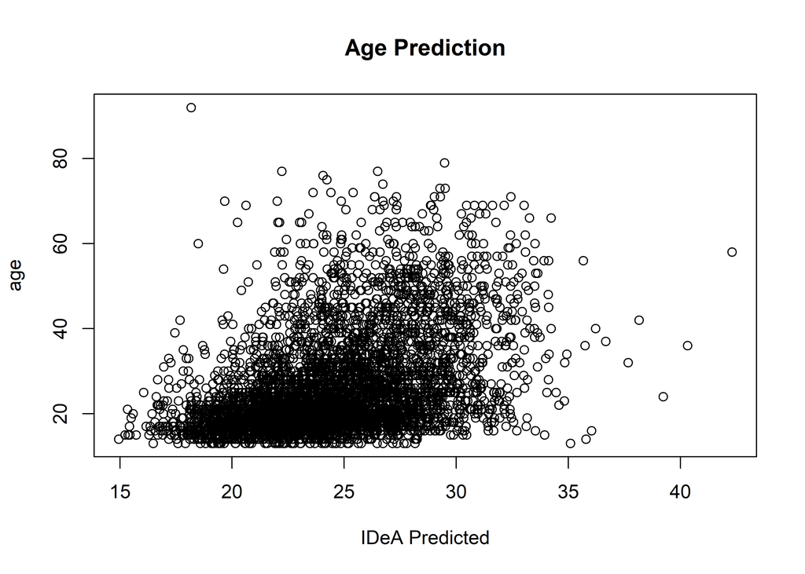

```r
plot(10^predOutcome_DE,10^testingset[,outcome],xlab="IDeA Predicted",ylab=outcome,main="Age Prediction")
```